# hate and offensive language classification

## Importing Required Libraries

```python
import pandas as pd
import numpy as np
import seaborn as sns
import matplotlib.pyplot as plt
from wordcloud import WordCloud
from collections import Counter
from sklearn.feature_extraction.text import TfidfVectorizer
from sklearn.decomposition import PCA
from sklearn.model_selection import train_test_split, GridSearchCV
from sklearn.linear_model import LogisticRegression
from sklearn.ensemble import RandomForestClassifier
from sklearn.svm import SVC
from sklearn.preprocessing import label_binarize
from sklearn.metrics import classification_report, confusion_matrix, roc_auc_score, roc_curve, accuracy_score, log_loss
from sklearn.preprocessing import StandardScaler
from sklearn.pipeline import make_pipeline
from sklearn.model_selection import GridSearchCV
import warnings
warnings.filterwarnings('ignore')
```

```python
import re
import string
import nltk
from nltk.util import pr
from nltk.stem import PorterStemmer, SnowballStemmer
from nltk.tokenize import word_tokenize      #to divide strings into lists of substrin
from nltk.corpus import stopwords
nltk.download('stopwords')          #to filterout useless data
stopword = set(stopwords.words('english'))
stopword.remove('not')  # Keep 'not' as it is important in negation
nltk.download('punkt_tab')
```

```
True
```

```python
ps = PorterStemmer()
sbs = SnowballStemmer('english')
```

## Importing Datasets

```python
df = pd.read_csv('Dataset/labeled_data.csv', index_col=0)
```

```python
df.head()
```

|  | count | hate_speech | offensive_language | neither | class | tweet |
| --- | --- | --- | --- | --- | --- | --- |
| 0 | 3 | 0 | 0 | 3 | 2 | !!! RT @mayasolovely: As a woman you shouldn't... |
| 1 | 3 | 0 | 3 | 0 | 1 | !!!!! RT @mleew17: boy dats cold...tyga dwn ba... |
| 2 | 3 | 0 | 3 | 0 | 1 | !!!!!!! RT @UrKindOfBrand Dawg!!!! RT @80sbaby... |
| 3 | 3 | 0 | 2 | 1 | 1 | !!!!!!!!! RT @C_G_Anderson: @viva_based she lo... |
| 4 | 6 | 0 | 6 | 0 | 1 | !!!!!!!!!!!!! RT @ShenikaRoberts: The shit you... |

### Data Understanding and Preprocessing

```python
df.shape
```

```
(24783, 6)
```

```python
df.columns
```

```
Index(['count', 'hate_speech', 'offensive_language', 'neither', 'class',
       'tweet'],
      dtype='object')
```

From the column of the dataset, we have 3 class of language:

1. hate speech
2. offensive language
3. neither of them

We have class column with the other columns as well so, for our classification model, we only need class and tweet columns. So, we dropped other columns.

```python
df.drop(['count', 'hate_speech', 'offensive_language', 'neither'], inplace=True, axis=1)
```

```python
df.head()
```

|  | class | tweet |
| --- | --- | --- |
| 0 | 2 | !!! RT @mayasolovely: As a woman you shouldn't... |
| 1 | 1 | !!!!! RT @mleew17: boy dats cold...tyga dwn ba... |
| 2 | 1 | !!!!!!! RT @UrKindOfBrand Dawg!!!! RT @80sbaby... |
| 3 | 1 | !!!!!!!!! RT @C_G_Anderson: @viva_based she lo... |
| 4 | 1 | !!!!!!!!!!!!! RT @ShenikaRoberts: The shit you... |

```python
df.info()
```

```
<class 'pandas.core.frame.DataFrame'>
Index: 24783 entries, 0 to 25296
Data columns (total 2 columns):
 #   Column  Non-Null Count  Dtype
---  ------  --------------  -----
 0   class   24783 non-null  int64
 1   tweet   24783 non-null  object
dtypes: int64(1), object(1)
memory usage: 580.9+ KB
```

### Check if there are any null values

```python
df.isnull().sum()
```

```
class    0
tweet    0
dtype: int64
```

### First of all, lets clean the data as we have lots of unwanted text and characters in our tweet columns.

```python
def remove_unwanted_text(text):

    # Remove 'RT' (Retweet indicator)
    text = re.sub(r'\bRT\b', '', text)

    # Remove URLs (Optional: you can keep this if needed)
    text = re.sub(r'http\S+|www.\S+|https\S+', '', text)

    # Remove Twitter handles (Optional: you can keep this if needed)
    text = re.sub(r'@\w+', '', text)

    # Remove the &amp tag from the text
    text = re.sub(r'&amp', '', text)

    # Remove non-alphabetic characters (keep spaces)
    text = re.sub('[^a-zA-Z\s]', '', text)

    return text
```

```python
df.tweet[0]
```

```
"!!! RT @mayasolovely: As a woman you shouldn't complain about cleaning up your house. &amp; as a man you should always take the trash out..."
```

```python
print(remove_unwanted_text(df.tweet[0]))
```

```
   As a woman you shouldnt complain about cleaning up your house  as a man you should always take the trash out
```

```python
df.tweet[2]
```

```
'!!!!!!! RT @UrKindOfBrand Dawg!!!! RT @80sbaby4life: You ever fuck a bitch and she start to cry? You be confused as shit'
```

```python
print(remove_unwanted_text(df.tweet[2]))
```

```
   Dawg   You ever fuck a bitch and she start to cry You be confused as shit
```

```python
df.tweet[20000]
```

```
"RT @lnMyOpinion: The nicer you are, the easier you're hurt. So just be a bitch"
```

```python
print(remove_unwanted_text(df.tweet[20000]))
```

```
  The nicer you are the easier youre hurt So just be a bitch
```

### Data Cleaning and Stemming

```python
def clean_and_preprocess_text(text):
    # Remove the unwanted text
    text = remove_unwanted_text(text)

    # Convert to lowercase
    text = text.lower()

    # Tokenize the text (split into words)
    words = word_tokenize(text)

    # Remove stopwords
    words = [ps.stem(word) for word in words if word not in stopword]

    # Rejoin the words back into a single string
    cleaned_text = ' '.join(words)

    return cleaned_text
```

```python
df.loc[:, 'cleaned_tweet'] = df['tweet'].apply(clean_and_preprocess_text)
df.head()
```

|  | class | tweet | cleaned_tweet |
| --- | --- | --- | --- |
| 0 | 2 | !!! RT @mayasolovely: As a woman you shouldn't... | woman shouldnt complain clean hous man alway t... |
| 1 | 1 | !!!!! RT @mleew17: boy dats cold...tyga dwn ba... | boy dat coldtyga dwn bad cuffin dat hoe st place |
| 2 | 1 | !!!!!!! RT @UrKindOfBrand Dawg!!!! RT @80sbaby... | dawg ever fuck bitch start cri confus shit |
| 3 | 1 | !!!!!!!!! RT @C_G_Anderson: @viva_based she lo... | look like tranni |
| 4 | 1 | !!!!!!!!!!!!! RT @ShenikaRoberts: The shit you... | shit hear might true might faker bitch told ya |

### Basic EDA - Exploratory Data Analysis

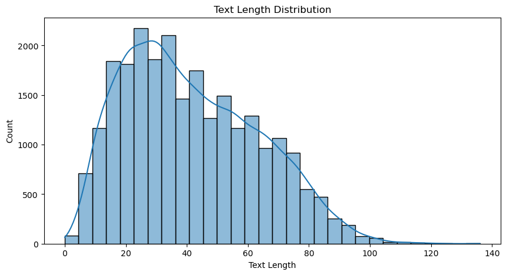

```python
df['text_length'] = df['cleaned_tweet'].apply(len)
plt.figure(figsize = (10, 5))
sns.histplot(df['text_length'], bins=30, kde=True)
plt.xlabel("Text Length")
plt.ylabel("Count")
plt.title("Text Length Distribution")
plt.show()
```

```python
# Generate the word cloud
hate_text = ' '.join(df[df['class'] == 0].cleaned_tweet)
hate_text
```

[output not shown]

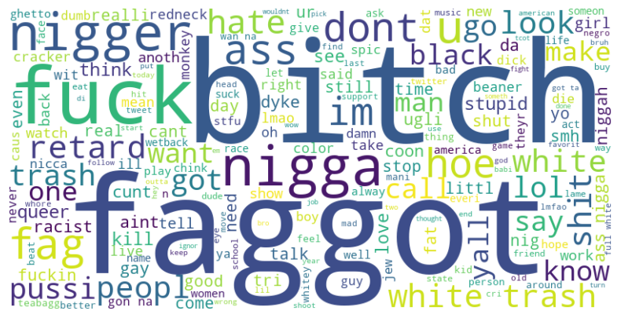

```python
wordcloud = WordCloud(width=800, height=400, background_color='white', colormap='viridis').generate(hate_text)

# Display the word cloud
plt.figure(figsize=(10, 5))
plt.imshow(wordcloud, interpolation='bilinear')
plt.axis('off')  # Turn off axes
plt.show()
```

```python
hate_text_words = hate_text.split()
hate_text_counts = Counter(hate_text_words)

# Step 3: Get the top 10 most frequent words
top_10_words = hate_text_counts.most_common(10)
top_10_words
```

```
[('bitch', 267),
 ('faggot', 247),
 ('fuck', 222),
 ('nigga', 215),
 ('like', 174),
 ('nigger', 168),
 ('ass', 138),
 ('white', 128),
 ('trash', 114),
 ('fag', 109)]
```

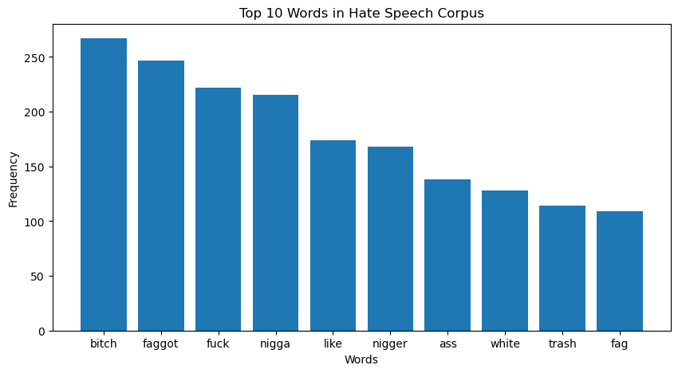

```python
words, counts = zip(*top_10_words)
plt.figure(figsize = (10, 5))
plt.bar(words, counts)
plt.xlabel("Words")
plt.ylabel("Frequency")
plt.title("Top 10 Words in Hate Speech Corpus")
plt.show()
```

```python
# Generate the word cloud
offensive_text = ' '.join(df[df['class'] == 1].cleaned_tweet)
offensive_text
```

[output not shown]

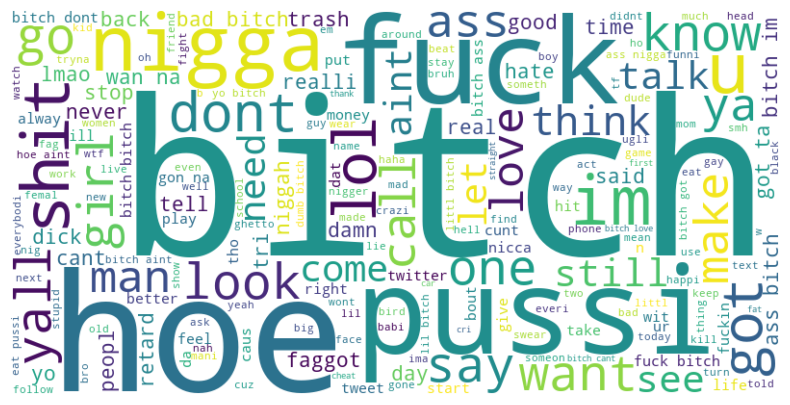

```python
wordcloud = WordCloud(width=800, height=400, background_color='white', colormap='viridis').generate(offensive_text)

# Display the word cloud
plt.figure(figsize=(10, 5))
plt.imshow(wordcloud, interpolation='bilinear')
plt.axis('off')  # Turn off axes
plt.show()
```

```python
offensive_text_words = offensive_text.split()
offensive_text_counts = Counter(offensive_text_words)

# Step 3: Get the top 10 most frequent words
top_10_words = offensive_text_counts.most_common(10)
top_10_words
```

```
[('bitch', 11054),
 ('hoe', 4143),
 ('like', 2369),
 ('pussi', 2157),
 ('fuck', 2029),
 ('im', 1777),
 ('nigga', 1776),
 ('dont', 1511),
 ('get', 1479),
 ('ass', 1447)]
```

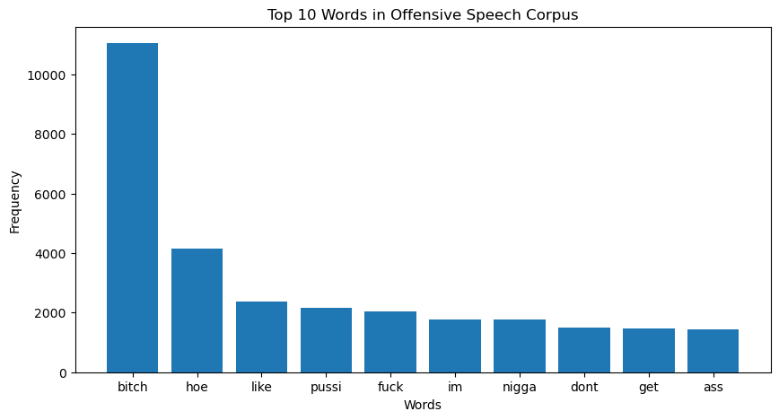

```python
words, counts = zip(*top_10_words)
plt.figure(figsize = (10, 5))
plt.bar(words, counts)
plt.xlabel("Words")
plt.ylabel("Frequency")
plt.title("Top 10 Words in Offensive Speech Corpus")
plt.show()
```

```python
# Generate the word cloud
neither_text = ' '.join(df[df['class'] == 2].cleaned_tweet)
neither_text
```

[output not shown]

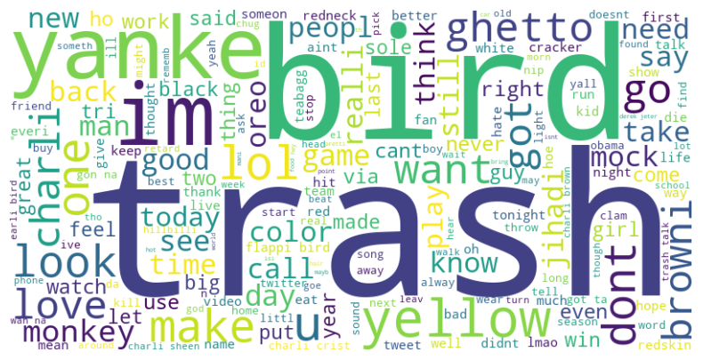

```python
wordcloud = WordCloud(width=800, height=400, background_color='white', colormap='viridis').generate(neither_text)

# Display the word cloud
plt.figure(figsize=(10, 5))
plt.imshow(wordcloud, interpolation='bilinear')
plt.axis('off')  # Turn off axes
plt.show()
```

```python
neither_text_words = neither_text.split()
neither_text_counts = Counter(neither_text_words)

# Step 3: Get the top 10 most frequent words
top_10_words = neither_text_counts.most_common(10)
top_10_words
```

```
[('trash', 693),
 ('bird', 461),
 ('like', 312),
 ('yanke', 277),
 ('charli', 261),
 ('im', 220),
 ('not', 219),
 ('yellow', 218),
 ('get', 217),
 ('dont', 174)]
```

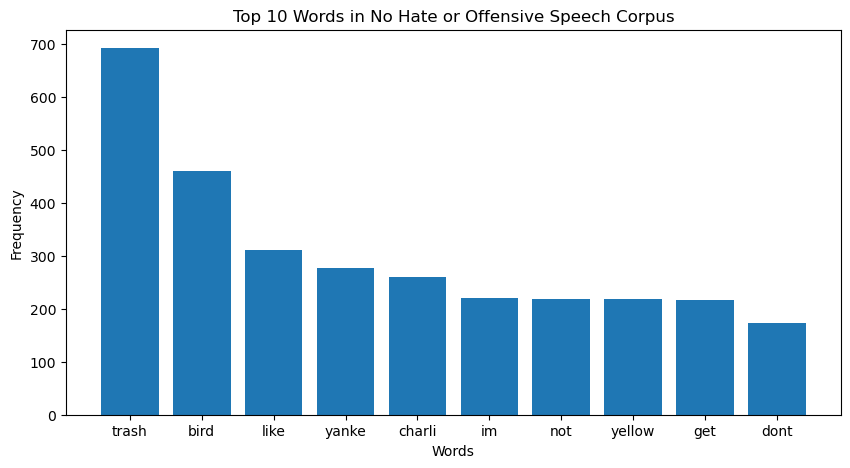

```python
words, counts = zip(*top_10_words)
plt.figure(figsize = (10, 5))
plt.bar(words, counts)
plt.xlabel("Words")
plt.ylabel("Frequency")
plt.title("Top 10 Words in No Hate or Offensive Speech Corpus")
plt.show()
```

### Check the value counts of each class i.e. offensive_langauage, hate_speech and neither.

```python
class_counts = df['class'].value_counts()
class_counts
```

```
class
1    19190
2     4163
0     1430
Name: count, dtype: int64
```

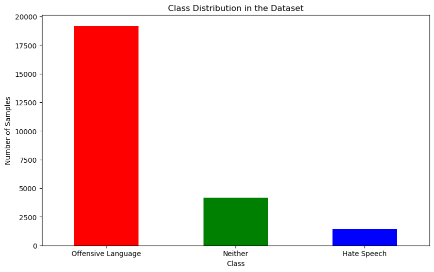

```python
class_labels = {0: 'Hate Speech', 1: 'Offensive Language', 2: 'Neither'}

plt.figure(figsize=(10, 6))
class_counts.rename(index=class_labels).plot(kind='bar', color=['red', 'green', 'blue'])
plt.title('Class Distribution in the Dataset')
plt.xlabel('Class')
plt.ylabel('Number of Samples')
plt.xticks(rotation=0)
plt.show()
```

### Feature Engineering

#### Balancing the dataset as we have great number of data in offensive language and less number of data in hate speech which will lead our model to have bias towards one class, so we are going to balance the dataset using minimum count.

```python
min_class_size = class_counts.min() #  1430

# Sample each class to match the smallest class size
df_class_0 = df[df['class'] == 0].sample(min_class_size)
df_class_1 = df[df['class'] == 1].sample(min_class_size)
df_class_2 = df[df['class'] == 2].sample(min_class_size)
```

```python
# Combine the sampled data
df_balanced = pd.concat([df_class_0, df_class_1, df_class_2])

# Shuffle the dataset
df_balanced = df_balanced.sample(frac=1, random_state=42).reset_index(drop=True)

# Check the class distribution
df_balanced['class'].value_counts()
```

```
class
2    1430
1    1430
0    1430
Name: count, dtype: int64
```

```python
df_balanced.head()
```

|  | class | tweet | cleaned_tweet | text_length |
| --- | --- | --- | --- | --- |
| 0 | 2 | #BlessJesusAir Matthew 6:26 Look at the birds ... | blessjesusair matthew look bird air yet heaven... | 84 |
| 1 | 1 | RT @Smokinonkaya_: She said I hurt her feeling... | said hurt feel date dyke | 24 |
| 2 | 2 | @Titan4Ever2488 some Mets fan tried telling me... | met fan tri tell rivera isnt best yanke time c... | 55 |
| 3 | 2 | apparently I'm pathetic trash alright (-: | appar im pathet trash alright | 29 |
| 4 | 2 | #WeAreRepublicNotRegime #POTUS BO violated USA... | wearerepublicnotregim potu bo violat usa sover... | 118 |

```python
df_balanced.dropna(inplace=True)
```

```python
X = df_balanced['cleaned_tweet']
y = df_balanced['class']
```

```python
X
```

```
0       blessjesusair matthew look bird air yet heaven...
1                                said hurt feel date dyke
2       met fan tri tell rivera isnt best yanke time c...
3                           appar im pathet trash alright
4       wearerepublicnotregim potu bo violat usa sover...
                              ...
4285                  devil wear charli revlon lesserfilm
4286    yay america israel put jew hate muslim trash g...
4287        bread gener aint good yabut honki bread worst
4288           grand open top class orient massag perfect
4289              ppl expect august aslina nig new orlean
Name: cleaned_tweet, Length: 4290, dtype: object
```

```python
X.isnull().sum()
```

```
0
```

Split dataset into training and testing sets

```python
X_train, X_test, y_train, y_test = train_test_split(X, y, test_size=0.2)
```

Extract feature using TF-IDF Vectorizer

```python
vectorizer = TfidfVectorizer(max_features=5000)
X_train = vectorizer.fit_transform(X_train).toarray()
X_test = vectorizer.transform(X_test).toarray()
```

```python
with open("Model/tfidf_vectorizer.pkl", "wb") as tfidf_file:
    pickle.dump(vectorizer, tfidf_file)
print("Models saved successfully!")
```

```
Models saved successfully!
```

```python
X_train.shape, X_test.shape
```

```
((3432, 5000), (858, 5000))
```

Scaling the features

```python
# scalar = StandardScaler()
# X_train = scalar.fit_transform(X_train)
# X_test = scalar.transform(X_test)
```

```python
# X_train.shape, X_test.shape
```

Dimensionality reduction using PCA

```python
pca = PCA(n_components=0.95)  # Retain 95% variance
X_train = pca.fit_transform(X_train)
X_test = pca.transform(X_test)
print(f"Reduced dimensions: {X_train.shape}")
print(f"Reduced dimensions: {X_test.shape}")
```

```
Reduced dimensions: (3432, 1979)
Reduced dimensions: (858, 1979)
```

```python
with open("Model/pca.pkl", "wb") as pca_file:
    pickle.dump(pca, pca_file)
print("Models saved successfully!")
```

```
Models saved successfully!
```

#### Check for outliers using boxplot (optional visualization)

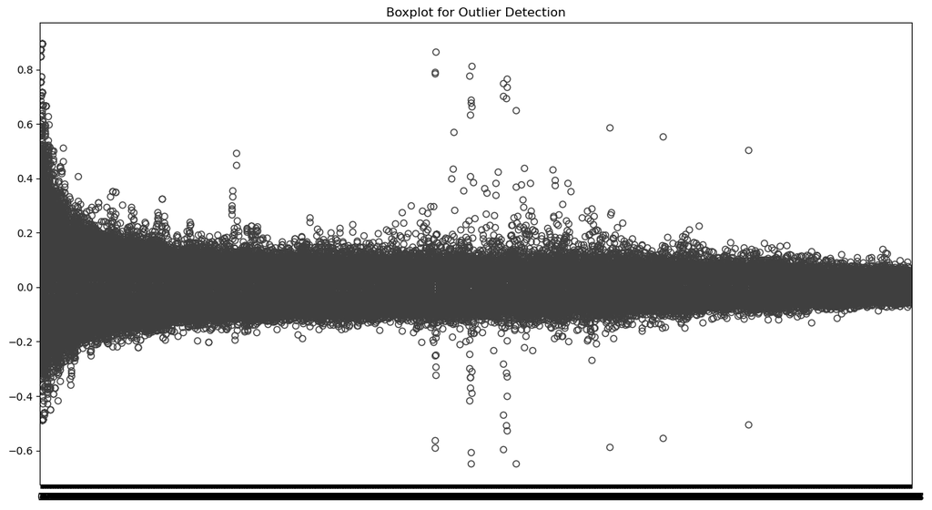

```python
plt.figure(figsize=(15, 8))
sns.boxplot(data=pd.DataFrame(X_train))
plt.title("Boxplot for Outlier Detection")
plt.show()
```

### Model Selection and Training

## Random Forest Classifier

```python
rf_model = RandomForestClassifier()
rf_model.fit(X_train, y_train)
```

```
RandomForestClassifier()
```

```python
y_pred = rf_model.predict(X_test)
```

```python
accuracy = accuracy_score(y_test, y_pred)
accuracy
```

```
0.7249417249417249
```

```python
# Define the parameter grid
rf_param_grid = {
    'n_estimators': [100, 200, 500],
    'max_depth': [10, 20, None],
    'min_samples_leaf': [1, 2, 4]
}
```

```python
# Perform GridSearchCV
rf_grid_search = GridSearchCV(estimator=rf_model, param_grid=rf_param_grid, cv=5, scoring='accuracy')
rf_grid_search.fit(X_train, y_train)
```

```
GridSearchCV(cv=5, estimator=RandomForestClassifier(),
             param_grid={'max_depth': [10, 20, None],
                         'min_samples_leaf': [1, 2, 4],
                         'n_estimators': [100, 200, 500]},
             scoring='accuracy')
```

```python
# Display the best parameters and score
print("Best parameters:", rf_grid_search.best_params_)
print("Best cross-validation score:", rf_grid_search.best_score_)
```

```
Best parameters: {'max_depth': None, 'min_samples_leaf': 4, 'n_estimators': 500}
Best cross-validation score: 0.7441782202587836
```

```python
y_pred = rf_grid_search.predict(X_test)
y_prob = rf_grid_search.predict_proba(X_test)  # Probabilities for each class
```

### Classification Report

```python
print("\nClassification Report:")
print(classification_report(y_test, y_pred, target_names=["Hate Speech", "Offensive Language", "Neither"]))
```

```
Classification Report:
                    precision    recall  f1-score   support

       Hate Speech       0.70      0.61      0.66       270
Offensive Language       0.77      0.80      0.78       280
           Neither       0.81      0.87      0.84       308

          accuracy                           0.77       858
         macro avg       0.76      0.76      0.76       858
      weighted avg       0.76      0.77      0.76       858
```

### Confusion Matrix

```python
cm = confusion_matrix(y_test, y_pred)
print("\nConfusion Matrix:")
print(cm)
```

```
Confusion Matrix:
[[166  57  47]
 [ 40 224  16]
 [ 30  10 268]]
```

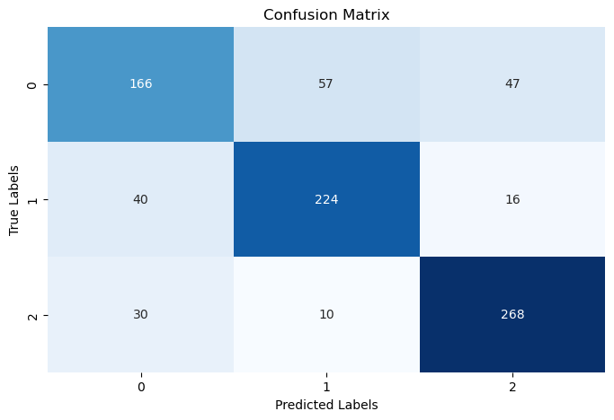

```python
# Visualize using seaborn heatmap
plt.figure(figsize=(8, 5))
sns.heatmap(cm, annot=True, fmt='d', cmap='Blues', cbar=False)
plt.xlabel('Predicted Labels')
plt.ylabel('True Labels')
plt.title('Confusion Matrix')
plt.show()
```

### AUC-ROC Curve

```python
# Binarize labels for multi-class AUC calculation
y_test_binarized = label_binarize(y_test, classes=[0, 1, 2])
fpr = {}
tpr = {}
roc_auc = {}
for i in range(3):  # One-vs-Rest ROC for each class
    fpr[i], tpr[i], _ = roc_curve(y_test_binarized[:, i], y_prob[:, i])
    roc_auc[i] = roc_auc_score(y_test_binarized[:, i], y_prob[:, i])
```

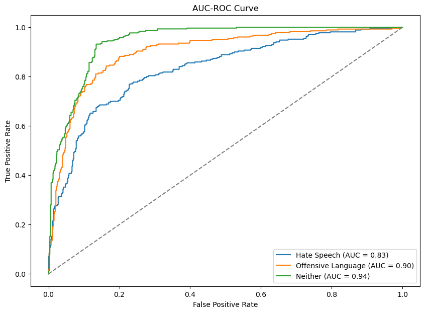

```python
# Plot ROC Curve
plt.figure(figsize=(10, 7))
for i, label in enumerate(["Hate Speech", "Offensive Language", "Neither"]):
    plt.plot(fpr[i], tpr[i], label=f"{label} (AUC = {roc_auc[i]:.2f})")
plt.plot([0, 1], [0, 1], linestyle="--", color="gray")  # Diagonal line
plt.xlabel("False Positive Rate")
plt.ylabel("True Positive Rate")
plt.title("AUC-ROC Curve")
plt.legend()
plt.show()
```

### Log Loss

```python
logloss = log_loss(y_test, y_prob)
print("\nLog Loss:", logloss)
```

```
Log Loss: 0.779169413337661
```

### Saving the Model

```python
import pickle

with open('Model/rf_model.pkl', 'wb') as f:
    pickle.dump(rf_grid_search, f)
```

## Logistic Regression

```python
lr_model = LogisticRegression()
lr_model.fit(X_train, y_train)
```

```
LogisticRegression()
```

```python
y_pred = lr_model.predict(X_test)
```

```python
accuracy = accuracy_score(y_test, y_pred)
accuracy
```

```
0.8181818181818182
```

```python
# Define the parameter grid
lr_param_grid = {
    'C': [0.1, 1, 10],
    'max_iter': [100, 500, 1000]
}
```

```python
# Perform GridSearchCV
lr_grid_search = GridSearchCV(estimator=lr_model, param_grid=lr_param_grid, cv=5, scoring='accuracy')
lr_grid_search.fit(X_train, y_train)
```

```
GridSearchCV(cv=5, estimator=LogisticRegression(),
             param_grid={'C': [0.1, 1, 10], 'max_iter': [100, 500, 1000]},
             scoring='accuracy')
```

```python
# Display the best parameters and score
print("Best parameters:", lr_grid_search.best_params_)
print("Best cross-validation score:", lr_grid_search.best_score_)
```

```
Best parameters: {'C': 1, 'max_iter': 100}
Best cross-validation score: 0.7966177363022564
```

```python
y_pred = lr_grid_search.predict(X_test)
y_prob = lr_grid_search.predict_proba(X_test)  # Probabilities for each class
```

```python
print("\nClassification Report:")
print(classification_report(y_test, y_pred, target_names=["Hate Speech", "Offensive Language", "Neither"]))
```

```
Classification Report:
                    precision    recall  f1-score   support

       Hate Speech       0.79      0.70      0.74       270
Offensive Language       0.81      0.78      0.79       280
           Neither       0.85      0.95      0.90       308

          accuracy                           0.82       858
         macro avg       0.81      0.81      0.81       858
      weighted avg       0.82      0.82      0.82       858
```

```python
cm = confusion_matrix(y_test, y_pred)
print("\nConfusion Matrix:")
print(cm)
```

```
Confusion Matrix:
[[190  48  32]
 [ 40 219  21]
 [ 11   4 293]]
```

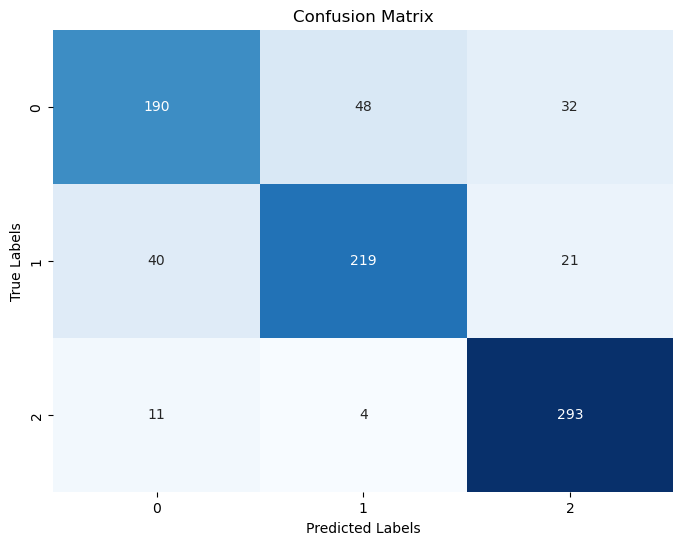

```python
# Visualize using seaborn heatmap
plt.figure(figsize=(8, 6))
sns.heatmap(cm, annot=True, fmt='d', cmap='Blues', cbar=False)
plt.xlabel('Predicted Labels')
plt.ylabel('True Labels')
plt.title('Confusion Matrix')
plt.show()
```

```python
# Binarize labels for multi-class AUC calculation
y_test_binarized = label_binarize(y_test, classes=[0, 1, 2])
fpr = {}
tpr = {}
roc_auc = {}
for i in range(3):  # One-vs-Rest ROC for each class
    fpr[i], tpr[i], _ = roc_curve(y_test_binarized[:, i], y_prob[:, i])
    roc_auc[i] = roc_auc_score(y_test_binarized[:, i], y_prob[:, i])
```

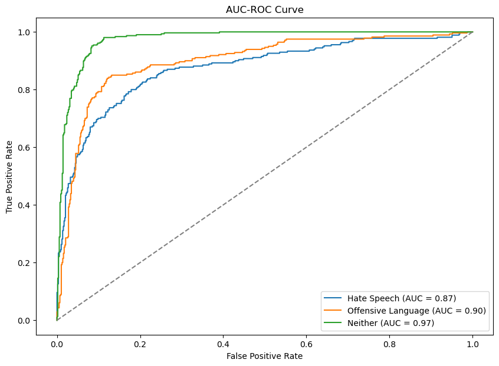

```python
# Plot ROC Curve
plt.figure(figsize=(10, 7))
for i, label in enumerate(["Hate Speech", "Offensive Language", "Neither"]):
    plt.plot(fpr[i], tpr[i], label=f"{label} (AUC = {roc_auc[i]:.2f})")
plt.plot([0, 1], [0, 1], linestyle="--", color="gray")  # Diagonal line
plt.xlabel("False Positive Rate")
plt.ylabel("True Positive Rate")
plt.title("AUC-ROC Curve")
plt.legend()
plt.show()
```

```python
logloss = log_loss(y_test, y_prob)
print("\nLog Loss:", logloss)
```

```
Log Loss: 0.5677081452646857
```

### Saving the Model

```python
import pickle

with open('Model/lr_model.pkl', 'wb') as f:
    pickle.dump(lr_grid_search, f)
```

## Support Vector Machine

```python
svc_model = SVC(probability=True)
svc_model.fit(X_train, y_train)
```

```
SVC(probability=True)
```

```python
y_pred = svc_model.predict(X_test)
```

```python
accuracy = accuracy_score(y_test, y_pred)
accuracy
```

```
0.8088578088578089
```

```python
# Define the parameter grid
svc_param_grid = {
    'C': [0.1, 1, 10],
    'kernel': ['linear', 'rbf'],
    'gamma': [0.1, 1, 10]
}
```

```python
# Perform GridSearchCV
svc_grid_search = GridSearchCV(estimator=svc_model, param_grid=svc_param_grid, cv=5, scoring='accuracy')
svc_grid_search.fit(X_train, y_train)
```

```
GridSearchCV(cv=5, estimator=SVC(probability=True),
             param_grid={'C': [0.1, 1, 10], 'gamma': [0.1, 1, 10],
                         'kernel': ['linear', 'rbf']},
             scoring='accuracy')
```

```python
# Display the best parameters and score
print("Best parameters:", svc_grid_search.best_params_)
print("Best cross-validation score:", svc_grid_search.best_score_)
```

```
Best parameters: {'C': 1, 'gamma': 0.1, 'kernel': 'linear'}
Best cross-validation score: 0.7916674093218073
```

```python
y_pred = svc_grid_search.predict(X_test)
y_prob = svc_grid_search.predict_proba(X_test)  # Probabilities for each class
```

### Classification Report

```python
print("\nClassification Report:")
print(classification_report(y_test, y_pred, target_names=["Hate Speech", "Offensive Language", "Neither"]))
```

```
Classification Report:
                    precision    recall  f1-score   support

       Hate Speech       0.76      0.70      0.73       270
Offensive Language       0.79      0.77      0.78       280
           Neither       0.86      0.94      0.90       308

          accuracy                           0.81       858
         macro avg       0.80      0.80      0.80       858
      weighted avg       0.81      0.81      0.81       858
```

### Confusion Matrix

```python
cm = confusion_matrix(y_test, y_pred)
print("\nConfusion Matrix:")
print(cm)
```

```
Confusion Matrix:
[[189  51  30]
 [ 46 216  18]
 [ 14   5 289]]
```

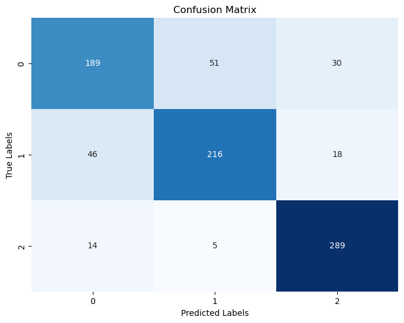

```python
# Visualize using seaborn heatmap
plt.figure(figsize=(8, 6))
sns.heatmap(cm, annot=True, fmt='d', cmap='Blues', cbar=False)
plt.xlabel('Predicted Labels')
plt.ylabel('True Labels')
plt.title('Confusion Matrix')
plt.show()
```

### AUC ROC Curve

```python
# Binarize labels for multi-class AUC calculation
y_test_binarized = label_binarize(y_test, classes=[0, 1, 2])
fpr = {}
tpr = {}
roc_auc = {}
for i in range(3):  # One-vs-Rest ROC for each class
    fpr[i], tpr[i], _ = roc_curve(y_test_binarized[:, i], y_prob[:, i])
    roc_auc[i] = roc_auc_score(y_test_binarized[:, i], y_prob[:, i])
```

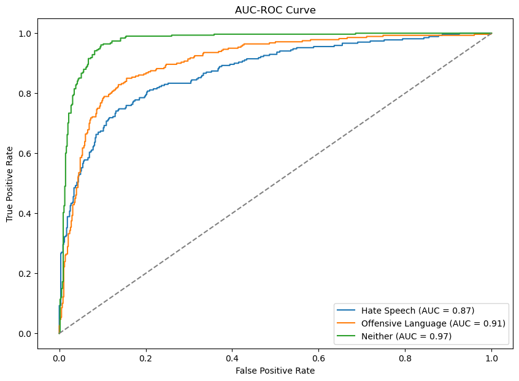

```python
# Plot ROC Curve
plt.figure(figsize=(10, 7))
for i, label in enumerate(["Hate Speech", "Offensive Language", "Neither"]):
    plt.plot(fpr[i], tpr[i], label=f"{label} (AUC = {roc_auc[i]:.2f})")
plt.plot([0, 1], [0, 1], linestyle="--", color="gray")  # Diagonal line
plt.xlabel("False Positive Rate")
plt.ylabel("True Positive Rate")
plt.title("AUC-ROC Curve")
plt.legend()
plt.show()
```

### Log Loss

```python
logloss = log_loss(y_test, y_prob)
print("\nLog Loss:", logloss)
```

```
Log Loss: 0.5246216852055645
```

### Saving the Model

```python
import pickle

with open('Model/svm_model.pkl', 'wb') as f:
    pickle.dump(svc_grid_search, f)
```

### The code below is for model deployment. This is a streamlit web app so this code should be run on VS Code.

```python
import streamlit as st
import pickle
import re
from nltk.tokenize import word_tokenize
from nltk.corpus import stopwords
from sklearn.feature_extraction.text import TfidfVectorizer
from sklearn.decomposition import PCA
import nltk
nltk.download('punkt')
nltk.download('stopwords')
stopword = set(stopwords.words('english'))
from nltk.stem.porter import PorterStemmer
ps = PorterStemmer()

# Load the TF-IDF Vectorizer
with open("Model/tfidf_vectorizer.pkl", "rb") as tfidf_file:
    vectorizer = pickle.load(tfidf_file)

# Load the PCA Model
with open("Model/pca.pkl", "rb") as pca_file:
    pca = pickle.load(pca_file)

# Load the Machine Learning Model
with open("Model/lr_model.pkl", "rb") as model_file:
    model = pickle.load(model_file)

# Function to remove unwanted text and characters
def remove_unwanted_text(text):
    text = re.sub(r'\bRT\b', '', text)  # Remove 'RT'
    text = re.sub(r'http\S+|www\S+|https\S+', '', text)  # Remove URLs
    text = re.sub(r'@\w+', '', text)  # Remove Twitter handles
    text = re.sub(r'&amp;', '', text)  # Remove '&amp;'
    text = re.sub(r'[^a-zA-Z\s]', ' ', text)  # Remove non-alphabetic characters
    return text

# Function to clean, preprocess, and stem text
def clean_and_preprocess_text(text):
    text = remove_unwanted_text(text)
    text = text.lower()  # Convert to lowercase
    words = word_tokenize(text)  # Tokenize text
    words = [ps.stem(word) for word in words if word not in stopword]  # Remove stopwords and stem
    cleaned_text = ' '.join(words)  # Rejoin words
    return cleaned_text

# Streamlit app interface
st.title("Hate Speech, Offensive Language and Neutral Language Classification")
st.write("Enter a tweet, and the model will classify it as *Hate Speech*, *Offensive Language*, or *Neither*.")

# Input text from user
tweet_input = st.text_input("Enter your tweet:")

if st.button("Classify"):
    if tweet_input:
        try:
            # Step 1: Clean and preprocess the input
            cleaned_tweet = clean_and_preprocess_text(tweet_input)

            # Step 2: Transform the input using the TF-IDF vectorizer
            vectorized_tweet = vectorizer.transform([cleaned_tweet]).toarray()

            # Step 3: Apply PCA transformation
            pca_transformed_tweet = pca.transform(vectorized_tweet)

            # Step 4: Predict using the Logistic Regression model
            prediction = model.predict(pca_transformed_tweet)
            prediction_proba = model.predict_proba(pca_transformed_tweet)

            # Map prediction to labels
            labels = {0: "Hate Speech", 1: "Offensive Language", 2: "Neither"}
            result = labels[prediction[0]]

            # Display result
            st.success(f"Prediction: *{result}*")
            st.write(f"Prediction Confidence: {max(prediction_proba[0]) * 100:.2f}%")

        except Exception as e:
            st.error(f"An error occurred: {e}")
    else:
        st.warning("Please enter a tweet to classify!")
```